# Initial EDA Basic Outline

Vydeepthi Dhulipalla

This is an outline for your Initial EDA. You can follow this outline, or you can modify it as you see fit. Do what works best for your project.

## Research Question

The research question for this project is: How do different factors such as GRE scores, GPA, undergraduate institution rank, socioeconomic status, gender, and race influence the admission of international students into colleges in the USA? This question is of interest as understanding the factors that impact admission can help improve the admission process and promote fairness and inclusivity.

## Data Processing

```r
library(tidyverse)
library(dplyr)
```

#### Data Intake

```r
# Import the first dataset
admission <- read.csv("Admission.csv")
head(admission)
```

|  | admit | gre | gpa | ses | Gender_Male | Race | rank |
| --- | --- | --- | --- | --- | --- | --- | --- |
| 1 | 0 | 380 | 3.61 | 1 | 0 | 3 | 3 |
| 2 | 1 | 660 | 3.67 | 2 | 0 | 2 | 3 |
| 3 | 1 | 800 | 4.00 | 2 | 0 | 2 | 1 |
| 4 | 1 | 640 | 3.19 | 1 | 1 | 2 | 4 |
| 5 | 0 | 520 | 2.93 | 3 | 1 | 2 | 4 |
| 6 | 1 | 760 | 3.00 | 2 | 1 | 1 | 2 |

```r
# Dataset description:
# Attribute Description
# GRE: Graduate Record Exam Scores
# GPA: Grade Point Average
# Rank: It refers to the prestige of the undergraduate institution. The variable rank takes on the values 1 through 4. Institutions with a rank of 1 have the highest prestige, while those with a rank of 4 have the lowest.
# Admit: It is a response variable; admit/don’t admit is a binary variable where 1 indicates that student is admitted and 0 indicates that student is not admitted.
# SES: SES refers to socioeconomic status: 1 - low, 2 - medium, 3 - high.
# Gender_male: Gender_male (0, 1) = 0 -> Female, 1 -> Male
# Race: Race – 1, 2, and 3 represent Hispanic, Asian, and African-American
```

```r
# Import the second dataset
prediction <- read.csv("Prediction.csv")
# Dataset description:
# GRE.Score: GRE score
# TOEFL.Score: TOEFL score
# University.Rating: University rating
# SOP: Statement of Purpose score
# LOR: Letter of Recommendation score
# CGPA: Cumulative GPA
# Research: Research experience
# Chance.of.Admit.: Predicted admission rate

head(prediction)
```

|  | Serial.No. | GRE.Score | TOEFL.Score | University.Rating | SOP | LOR. | CGPA | Research | Chance.of.Admit. |
| --- | --- | --- | --- | --- | --- | --- | --- | --- | --- |
| 1 | 1 | 337 | 118 | 4 | 4.5 | 4.5 | 9.65 | 1 | 0.92 |
| 2 | 2 | 324 | 107 | 4 | 4.0 | 4.5 | 8.87 | 1 | 0.76 |
| 3 | 3 | 316 | 104 | 3 | 3.0 | 3.5 | 8.00 | 1 | 0.72 |
| 4 | 4 | 322 | 110 | 3 | 3.5 | 2.5 | 8.67 | 1 | 0.80 |
| 5 | 5 | 314 | 103 | 2 | 2.0 | 3.0 | 8.21 | 0 | 0.65 |
| 6 | 6 | 330 | 115 | 5 | 4.5 | 3.0 | 9.34 | 1 | 0.90 |

#### Data Wrangling

```r
# Filter rows based on a condition
filtered_data <- admission %>%
  filter(gre > 600)

# Mutate to create a new variable
mutated_data <- admission %>%
  mutate(total_score = gre + gpa)

# Summarize data by a variable
summarized_data <- admission %>%
  group_by(Race) %>%
  summarise(avg_gre = mean(gre))

# Joining the datasets
merged_data <- inner_join(admission, prediction, by = c("gre" = "GRE.Score"))
# Print the merged dataset
View(merged_data)
```

## Data Visualization

#### Plot 1

Description: The scatter plot shows the relationship between GRE score and CGPA, with the points colored according to the chance of admission. This visualization helps us understand if there is any correlation between GRE score, CGPA, and the likelihood of admission. From the plot, we can observe if higher GRE scores and CGPA are associated with a higher chance of admission. This graph can be helpful in answering the research question by providing initial insights into the relationship between these variables.

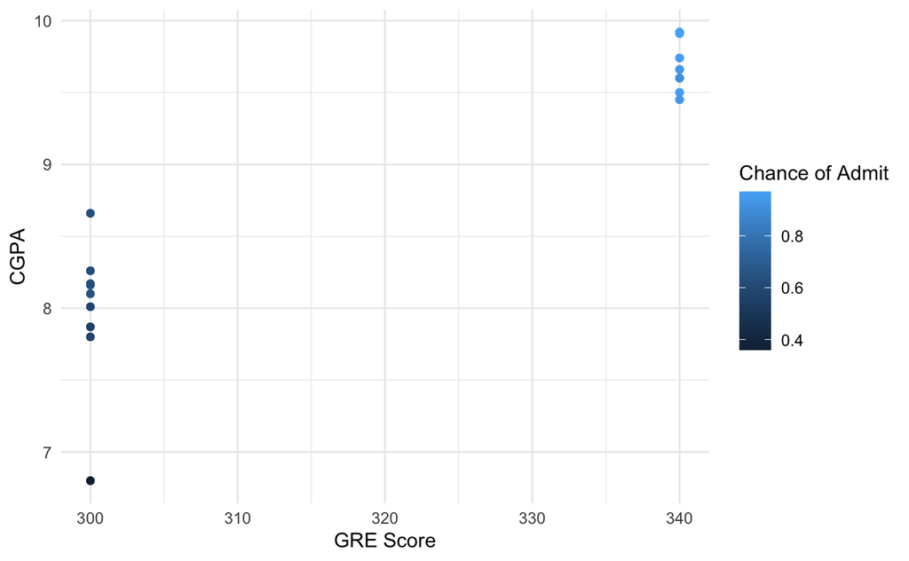

```r
library(ggplot2)

# Scatter plot
ggplot(data = merged_data, aes(x = gre, y = CGPA, color = Chance.of.Admit.)) +
  geom_point() +
  labs(x = "GRE Score", y = "CGPA", color = "Chance of Admit") +
  theme_minimal()
```

#### Plot 2

The bar plot displays the count of observations based on GRE score, with the bars filled according to gender. The plot is divided into panels based on the different values of the chance of admission. This visualization allows us to examine the distribution of GRE scores among different genders and their relationship to the chance of admission. It provides insights into any gender disparities in admissions based on GRE scores. This graph can be helpful in answering the research question by examining potential gender-based biases in admissions related to GRE scores.

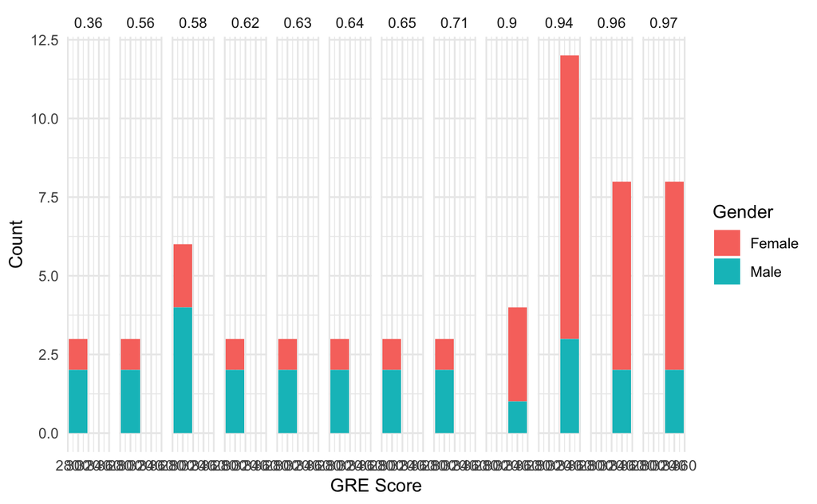

```r
# Convert Gender_Male to factor
merged_data$Gender_Male <- factor(merged_data$Gender_Male, labels = c("Female", "Male"))

# Bar plot
ggplot(data = merged_data, aes(x = gre, fill = Gender_Male)) +
  geom_bar() +
  labs(x = "GRE Score", y = "Count", fill = "Gender") +
  facet_wrap(~Chance.of.Admit., nrow = 1) +
  theme_minimal()
```